# Bayesian Inferance Coding

## Model Random Intercepts, Covariates with Random Slopes:

Likelihood:

$$y_{ij}|\mu_{ij},\sigma^2 \sim
N(\mu_{ij},\sigma^2)$$

$$\mu_{ij}|\beta =
\beta_0+\beta_{0(j)}+\beta_1log(uranium)_{ij}+\beta_{2(j)}floor_{ij}$$

Priors:

$$\sigma \sim \pi(\sigma)$$
$$\beta_{0j}|\sigma^2_{\beta_0} \sim
N(0,\sigma_{\beta_0}^2)$$
$$\beta_{k}
\sim N(0,C)$$

$$\beta_{2(j)}|\beta_2,\sigma_{\beta_2}^2
\sim N(\beta_2,\sigma_{\beta_2}^2)$$

Hyperpriors(Hyperparameters):

$$\begin{equation}
\Sigma =
\begin{pmatrix}
\sigma_{\beta_0}^2 & \sigma_{\beta_0,\beta_2} \\
\sigma_{\beta_0,\beta_2} & \sigma_{\beta_2}^2\\
\end{pmatrix} = \pi(\Sigma)
\end{equation}$$

```r
mod3=stan_lmer(log_radon~log_uranium+floor+(1+floor|county),data=df2)
summary(mod3)
```

```
##
## Model Info:
##  function:     stan_lmer
##  family:       gaussian [identity]
##  formula:      log_radon ~ log_uranium + floor + (1 + floor | county)
##  algorithm:    sampling
##  sample:       4000 (posterior sample size)
##  priors:       see help('prior_summary')
##  observations: 919
##  groups:       county (85)
##
## Estimates:
##                                         mean   sd   10%   50%   90%
## (Intercept)                            1.5    0.0  1.4   1.5   1.5
## log_uranium                            0.7    0.1  0.6   0.7   0.8
## floorfirst                            -0.6    0.1 -0.7  -0.6  -0.5
## b[(Intercept) county:AITKIN]           0.0    0.1 -0.2   0.0   0.1
## b[floorfirst county:AITKIN]            0.1    0.3 -0.2   0.0   0.4
## b[(Intercept) county:ANOKA]            0.0    0.1 -0.1   0.0   0.1
## b[floorfirst county:ANOKA]            -0.1    0.2 -0.4  -0.1   0.1
## b[(Intercept) county:BECKER]           0.0    0.1 -0.1   0.0   0.2
## b[floorfirst county:BECKER]            0.0    0.2 -0.3   0.0   0.3
## b[(Intercept) county:BELTRAMI]         0.1    0.1 -0.1   0.1   0.3
## b[floorfirst county:BELTRAMI]          0.1    0.2 -0.1   0.1   0.4
## b[(Intercept) county:BENTON]           0.0    0.1 -0.2   0.0   0.2
## b[floorfirst county:BENTON]            0.0    0.2 -0.2   0.0   0.3
## b[(Intercept) county:BIGSTONE]         0.0    0.1 -0.2   0.0   0.1
## b[floorfirst county:BIGSTONE]          0.0    0.3 -0.3   0.0   0.3
## b[(Intercept) county:BLUEEARTH]        0.1    0.1  0.0   0.1   0.3
## b[floorfirst county:BLUEEARTH]         0.2    0.3 -0.1   0.2   0.6
## b[(Intercept) county:BROWN]            0.0    0.1 -0.1   0.0   0.2
## b[floorfirst county:BROWN]             0.0    0.2 -0.2   0.0   0.3
## b[(Intercept) county:CARLTON]         -0.1    0.1 -0.2   0.0   0.1
## b[floorfirst county:CARLTON]           0.1    0.3 -0.2   0.1   0.5
## b[(Intercept) county:CARVER]           0.0    0.1 -0.1   0.0   0.2
## b[floorfirst county:CARVER]           -0.1    0.2 -0.4  -0.1   0.2
## b[(Intercept) county:CASS]             0.1    0.1 -0.1   0.0   0.2
## b[floorfirst county:CASS]              0.0    0.3 -0.3   0.0   0.3
## b[(Intercept) county:CHIPPEWA]         0.0    0.1 -0.2   0.0   0.2
## b[floorfirst county:CHIPPEWA]          0.0    0.3 -0.3   0.0   0.3
```

[output cut: 325 more lines]

```
## b[floorfirst county:WILKIN]           0.0  1.0  6418
## b[(Intercept) county:WINONA]          0.0  1.0  3599
## b[floorfirst county:WINONA]           0.0  1.0  1458
## b[(Intercept) county:WRIGHT]          0.0  1.0  5296
## b[floorfirst county:WRIGHT]           0.0  1.0  5492
## b[(Intercept) county:YELLOWMEDICINE]  0.0  1.0  7111
## b[floorfirst county:YELLOWMEDICINE]   0.0  1.0  5642
## sigma                                 0.0  1.0  3801
## Sigma[county:(Intercept),(Intercept)] 0.0  1.0  1552
## Sigma[county:floorfirst,(Intercept)]  0.0  1.0  1200
## Sigma[county:floorfirst,floorfirst]   0.0  1.0   907
## mean_PPD                              0.0  1.0  5033
## log-posterior                         0.5  1.0   733
##
## For each parameter, mcse is Monte Carlo standard error, n_eff is a crude measure of effective sample size, and Rhat is the potential scale reduction factor on split chains (at convergence Rhat=1).
```

Sigma[county:floorfirst,floorfirst] variables neff seems problematic which might mean problem in autocorrelation.

```r
mod3.1 <- update (mod3 , iter =5000)
summary(mod3.1)
```

```
##
## Model Info:
##  function:     stan_lmer
##  family:       gaussian [identity]
##  formula:      log_radon ~ log_uranium + floor + (1 + floor | county)
##  algorithm:    sampling
##  sample:       10000 (posterior sample size)
##  priors:       see help('prior_summary')
##  observations: 919
##  groups:       county (85)
##
## Estimates:
##                                         mean   sd   10%   50%   90%
## (Intercept)                            1.5    0.0  1.4   1.5   1.5
## log_uranium                            0.7    0.1  0.6   0.7   0.8
## floorfirst                            -0.6    0.1 -0.7  -0.6  -0.5
## b[(Intercept) county:AITKIN]           0.0    0.1 -0.2   0.0   0.1
## b[floorfirst county:AITKIN]            0.1    0.3 -0.2   0.0   0.4
## b[(Intercept) county:ANOKA]            0.0    0.1 -0.1   0.0   0.1
## b[floorfirst county:ANOKA]            -0.1    0.2 -0.4  -0.1   0.2
## b[(Intercept) county:BECKER]           0.0    0.1 -0.2   0.0   0.2
## b[floorfirst county:BECKER]            0.0    0.2 -0.3   0.0   0.3
## b[(Intercept) county:BELTRAMI]         0.1    0.1 -0.1   0.1   0.3
## b[floorfirst county:BELTRAMI]          0.1    0.2 -0.1   0.1   0.4
## b[(Intercept) county:BENTON]           0.0    0.1 -0.2   0.0   0.2
## b[floorfirst county:BENTON]            0.0    0.3 -0.3   0.0   0.4
## b[(Intercept) county:BIGSTONE]         0.0    0.1 -0.2   0.0   0.1
## b[floorfirst county:BIGSTONE]          0.0    0.3 -0.3   0.0   0.3
## b[(Intercept) county:BLUEEARTH]        0.1    0.1  0.0   0.1   0.3
## b[floorfirst county:BLUEEARTH]         0.2    0.3 -0.1   0.2   0.6
## b[(Intercept) county:BROWN]            0.0    0.1 -0.1   0.0   0.2
## b[floorfirst county:BROWN]             0.0    0.2 -0.3   0.0   0.3
## b[(Intercept) county:CARLTON]         -0.1    0.1 -0.2   0.0   0.1
## b[floorfirst county:CARLTON]           0.1    0.3 -0.2   0.1   0.5
## b[(Intercept) county:CARVER]           0.0    0.1 -0.2   0.0   0.1
## b[floorfirst county:CARVER]           -0.1    0.2 -0.4  -0.1   0.2
## b[(Intercept) county:CASS]             0.1    0.1 -0.1   0.0   0.2
## b[floorfirst county:CASS]              0.0    0.3 -0.3   0.0   0.3
## b[(Intercept) county:CHIPPEWA]         0.0    0.1 -0.2   0.0   0.2
## b[floorfirst county:CHIPPEWA]          0.0    0.3 -0.3   0.0   0.3
```

[output cut: 325 more lines]

```
## b[floorfirst county:WILKIN]           0.0  1.0  16090
## b[(Intercept) county:WINONA]          0.0  1.0   8534
## b[floorfirst county:WINONA]           0.0  1.0   3762
## b[(Intercept) county:WRIGHT]          0.0  1.0  15162
## b[floorfirst county:WRIGHT]           0.0  1.0  15104
## b[(Intercept) county:YELLOWMEDICINE]  0.0  1.0  16908
## b[floorfirst county:YELLOWMEDICINE]   0.0  1.0  13917
## sigma                                 0.0  1.0   8278
## Sigma[county:(Intercept),(Intercept)] 0.0  1.0   3347
## Sigma[county:floorfirst,(Intercept)]  0.0  1.0   3597
## Sigma[county:floorfirst,floorfirst]   0.0  1.0   2438
## mean_PPD                              0.0  1.0  11055
## log-posterior                         0.3  1.0   1766
##
## For each parameter, mcse is Monte Carlo standard error, n_eff is a crude measure of effective sample size, and Rhat is the potential scale reduction factor on split chains (at convergence Rhat=1).
```

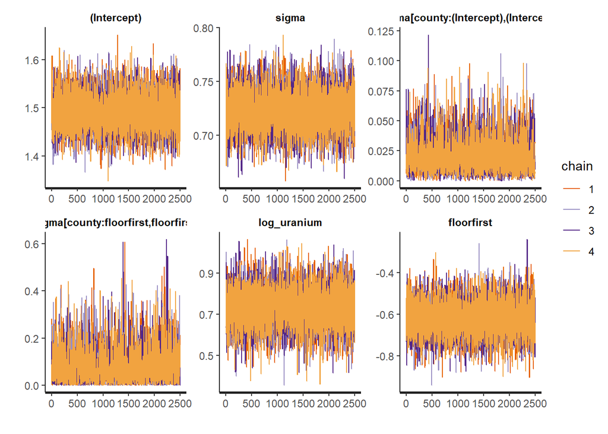

```r
stan_trace(mod3.1,pars=c("(Intercept)","sigma","Sigma[county:(Intercept),(Intercept)]"
                         ,"Sigma[county:floorfirst,floorfirst]","log_uranium","floorfirst"))
```

No issue with the convergence.

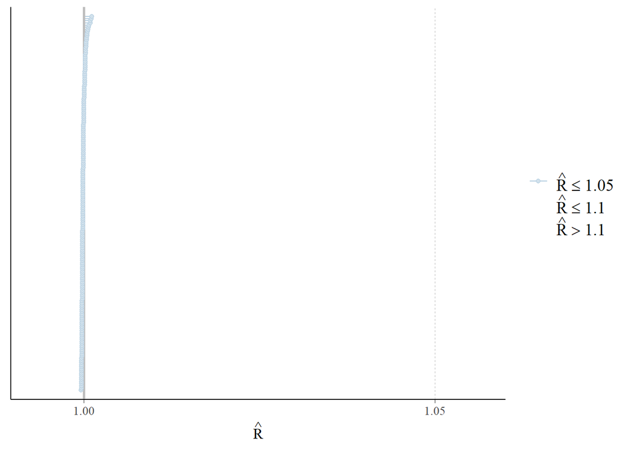

```r
plot(mod3.1,plotfun="rhat")
```

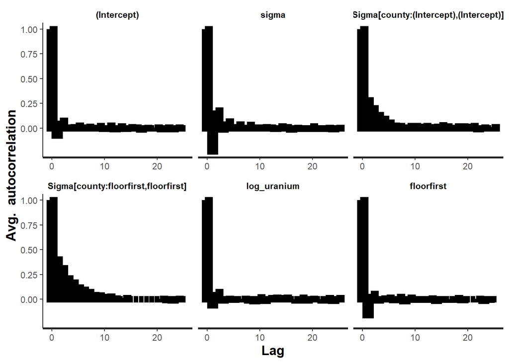

```r
stan_ac(mod3.1,pars=c("(Intercept)","sigma","Sigma[county:(Intercept),(Intercept)]"
                         ,"Sigma[county:floorfirst,floorfirst]","log_uranium","floorfirst"))
```

Sigma[county:floorfirst,floorsfirst] variable shows autocorrelation since it has slow decay in the acf plot.

Model Choice:

```r
waic(mod3.1)
```

```
##
## Computed from 10000 by 919 log-likelihood matrix.
##
##           Estimate   SE
## elpd_waic  -1028.5 29.6
## p_waic        44.0  5.3
## waic        2057.1 59.1
##
## 21 (2.3%) p_waic estimates greater than 0.4. We recommend trying loo instead.
```

```r
waic(model_ri_cov)
```

```
##
## Computed from 4000 by 919 log-likelihood matrix.
##
##           Estimate   SE
## elpd_waic  -1027.0 28.7
## p_waic        25.1  2.2
## waic        2054.0 57.5
##
## 6 (0.7%) p_waic estimates greater than 0.4. We recommend trying loo instead.
```

```r
waic(random_intercept_mod)
```

```
##
## Computed from 4000 by 919 log-likelihood matrix.
##
##           Estimate   SE
## elpd_waic  -1083.2 28.9
## p_waic        44.1  4.1
## waic        2166.4 57.7
##
## 10 (1.1%) p_waic estimates greater than 0.4. We recommend trying loo instead.
```

Model with covariates and random intercept has lower WAIC which means that it is better choose that model.

#### Summary of the Better Model:

```r
main_pars=c("log_uranium","floorfirst","(Intercept)","Sigma[county:(Intercept),(Intercept)]")
summary(model_ri_cov,pars=main_pars)
```

```
##
## Model Info:
##  function:     stan_lmer
##  family:       gaussian [identity]
##  formula:      log_radon ~ (1 | county) + log_uranium + floor
##  algorithm:    sampling
##  sample:       4000 (posterior sample size)
##  priors:       see help('prior_summary')
##  observations: 919
##  groups:       county (85)
##
## Estimates:
##                                         mean   sd   10%   50%   90%
## (Intercept)                            1.5    0.0  1.4   1.5   1.5
## log_uranium                            0.7    0.1  0.6   0.7   0.8
## floorfirst                            -0.6    0.1 -0.7  -0.6  -0.6
## Sigma[county:(Intercept),(Intercept)]  0.0    0.0  0.0   0.0   0.0
##
## MCMC diagnostics
##                                       mcse Rhat n_eff
## (Intercept)                           0.0  1.0  2854
## log_uranium                           0.0  1.0  3069
## floorfirst                            0.0  1.0  4902
## Sigma[county:(Intercept),(Intercept)] 0.0  1.0  1037
##
## For each parameter, mcse is Monte Carlo standard error, n_eff is a crude measure of effective sample size, and Rhat is the potential scale reduction factor on split chains (at convergence Rhat=1).
```

Posterior Intervals:

```r
posterior_interval(model_ri_cov,prob=0.9,pars="log_uranium")
```

```
##                    5%     95%
## log_uranium 0.5526083 0.83867
```

$\alpha = 1-P$ since prob = 0.9 here alpha will equal to 0.1.

```r
posterior_interval(model_ri_cov,prob=0.8,pars="log_uranium")
```

```
##                   10%       90%
## log_uranium 0.5882288 0.8083015
```

Posterior Predictive Checks:

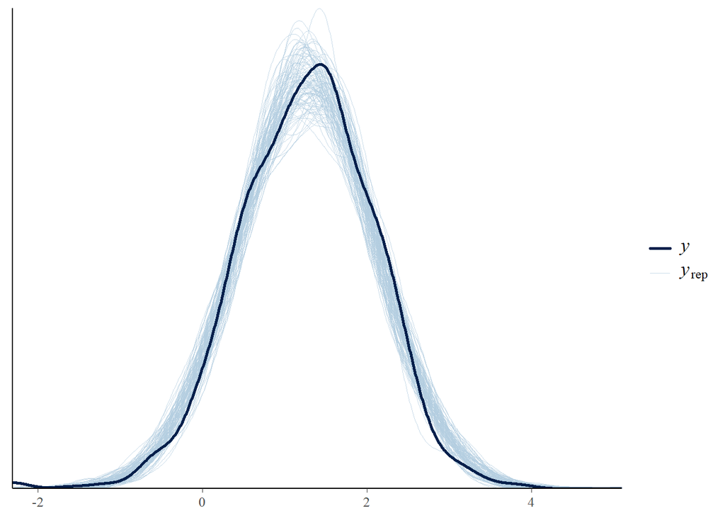

```r
yhat=posterior_predict(model_ri_cov)
ppc_dens_overlay(y=df2$log_radon,yrep = yhat[1100:1200,])
```

Seem appropiriate.

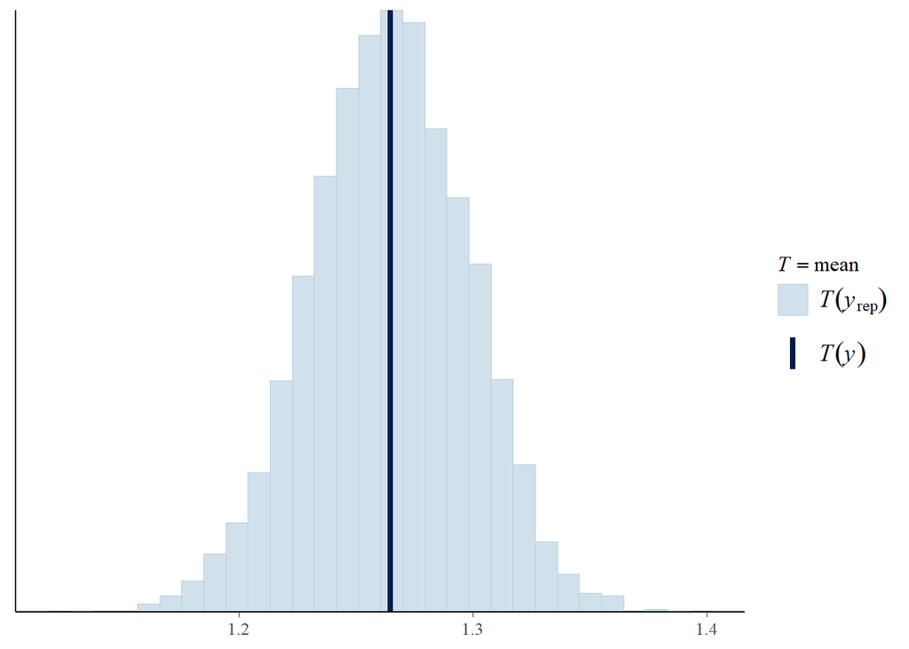

```r
ppc_stat(y=df2$log_radon,yrep=yhat,stat="mean")
```

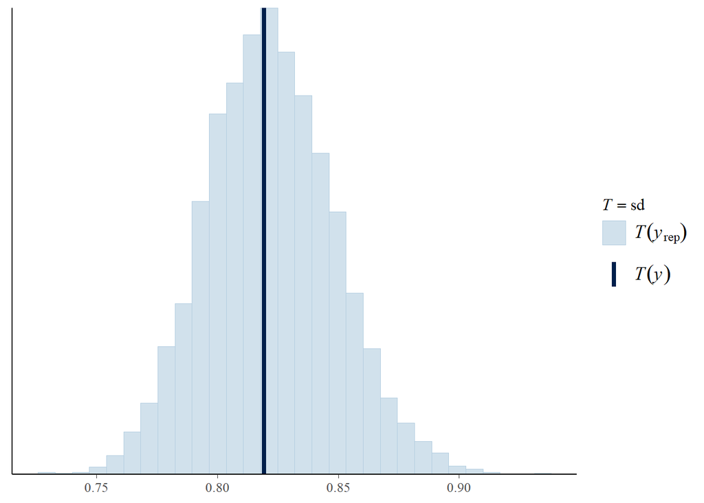

```r
ppc_stat(y=df2$log_radon,yrep=yhat,stat="sd")
```

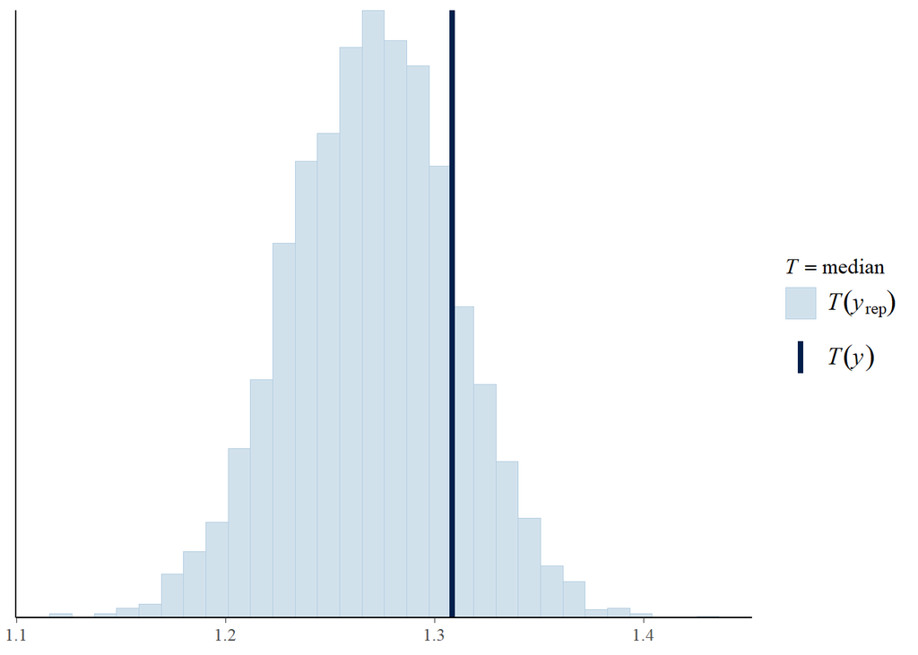

```r
ppc_stat(y=df2$log_radon,yrep=yhat,stat="median")
```

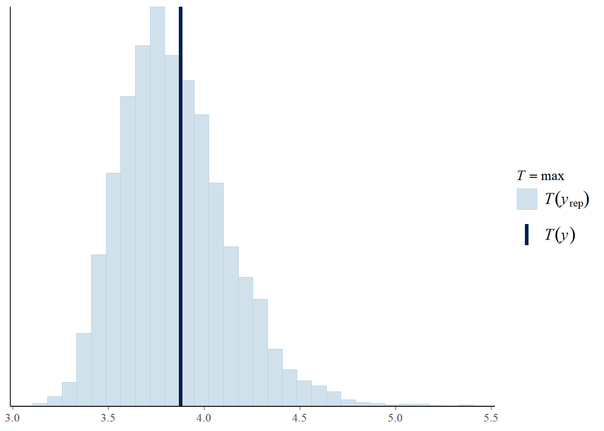

```r
ppc_stat(y=df2$log_radon,yrep=yhat,stat="max")
```

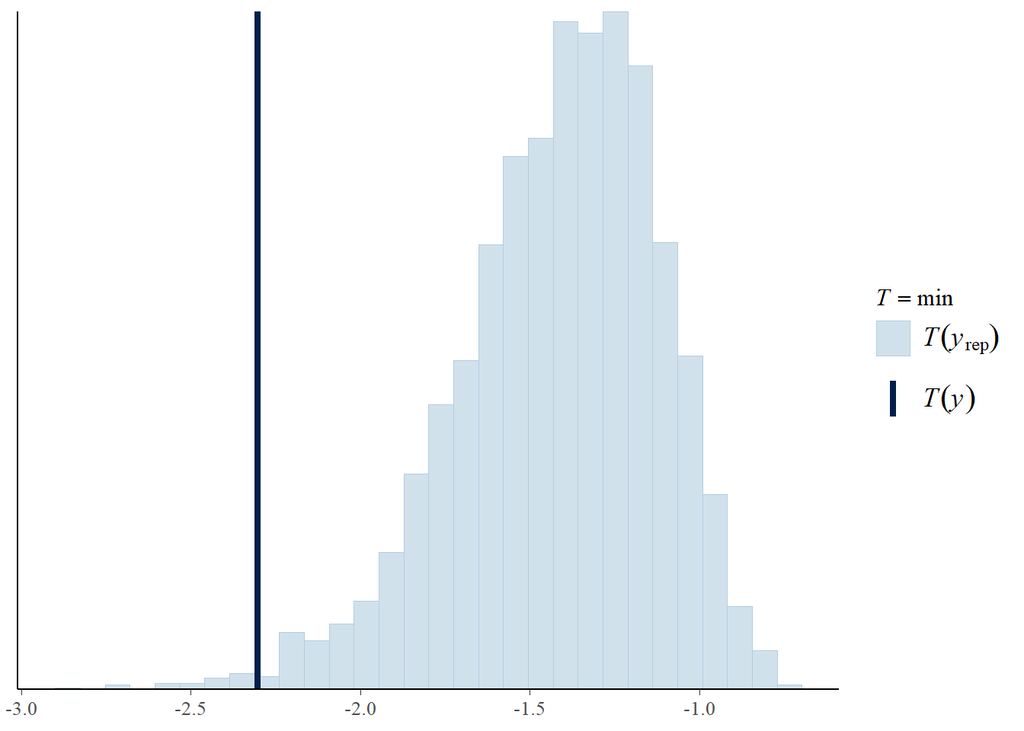

```r
ppc_stat(y=df2$log_radon,yrep=yhat,stat="min")
```

# Creating Logistics Regression Model:

It is a GLM with the Bernoulli (or binomial) distribution assumed for data and the linear predictor (function of the covariate pattern xi ) is specified for a suitable transformation of the probability. In particular, the logit function is used:

$$y_i|p_i \sim Ber(p_i)$$

$$log(\frac{p_i}{1-p_i})|\beta =
X^T\beta$$

Simple Logistics Regression:

$$log(\frac{P_i}{1-P_i})|\beta =
\beta_0+\beta_1race+\beta_2gender$$

Logistics Regression with Random Intercept:

$$log(\frac{P_{ij}}{1-P_{ij}})|\beta =
\beta_0+\beta_{0(j)}+\beta_1race+\beta_2gender$$

```r
df3=read.csv("Data_Ex_3.csv",header=T)
head(df3)
```

```
##   bush black female state
## 1    1    no    yes    42
## 2    1    no    yes    23
## 3    1    no    yes    44
## 4    0    no    yes    44
## 5    1    no     no    14
## 6    1    no    yes    36
```

```r
mod_bin=stan_glm(bush~black+female,data=df3,family="binomial",iter=4000,warmup=2000)
summary(mod_bin)
```

```
##
## Model Info:
##  function:     stan_glm
##  family:       binomial [logit]
##  formula:      bush ~ black + female
##  algorithm:    sampling
##  sample:       8000 (posterior sample size)
##  priors:       see help('prior_summary')
##  observations: 2591
##  predictors:   3
##
## Estimates:
##               mean   sd   10%   50%   90%
## (Intercept)  0.4    0.1  0.3   0.4   0.5
## blackyes    -1.5    0.2 -1.7  -1.5  -1.3
## femaleyes   -0.1    0.1 -0.2  -0.1   0.1
##
## Fit Diagnostics:
##            mean   sd   10%   50%   90%
## mean_PPD 0.6    0.0  0.5   0.6   0.6
##
## The mean_ppd is the sample average posterior predictive distribution of the outcome variable (for details see help('summary.stanreg')).
##
## MCMC diagnostics
##               mcse Rhat n_eff
## (Intercept)   0.0  1.0  8869
## blackyes      0.0  1.0  7668
## femaleyes     0.0  1.0  8083
## mean_PPD      0.0  1.0  7753
## log-posterior 0.0  1.0  3682
##
## For each parameter, mcse is Monte Carlo standard error, n_eff is a crude measure of effective sample size, and Rhat is the potential scale reduction factor on split chains (at convergence Rhat=1).
```

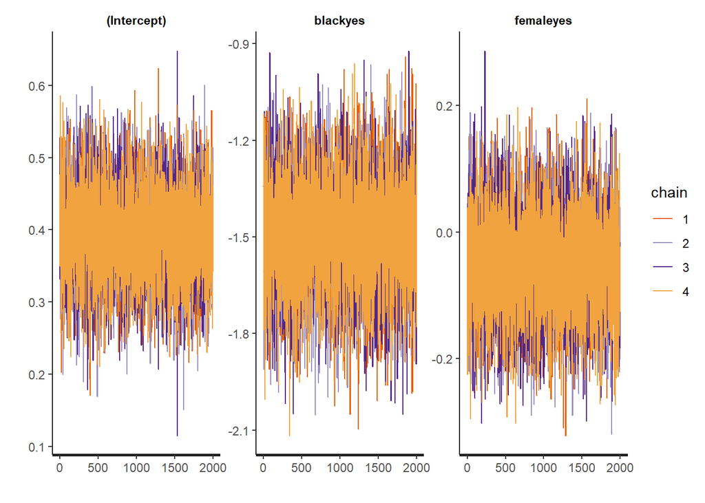

```r
stan_trace(mod_bin)
```

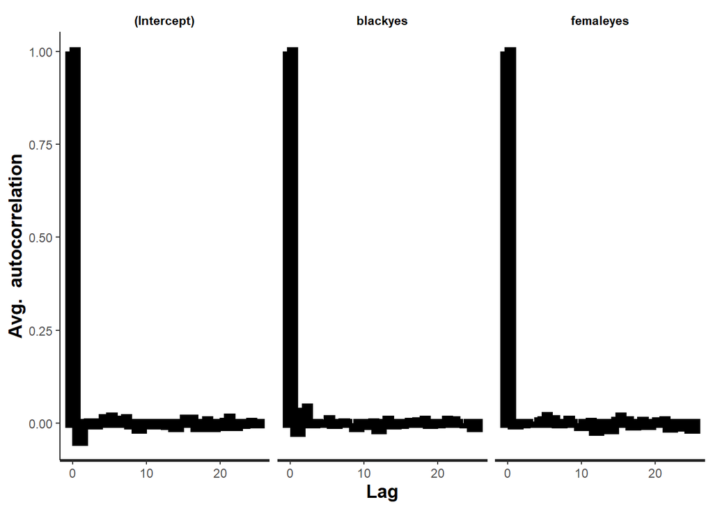

```r
stan_ac(mod_bin)
```

```r
mod_bin_ri=stan_glmer(bush~black+female+(1|state),data=df3,family="binomial",iter=4000,warmup=2000)
summary(mod_bin_ri)
```

```
##
## Model Info:
##  function:     stan_glmer
##  family:       binomial [logit]
##  formula:      bush ~ black + female + (1 | state)
##  algorithm:    sampling
##  sample:       8000 (posterior sample size)
##  priors:       see help('prior_summary')
##  observations: 2591
##  groups:       state (49)
##
## Estimates:
##                                        mean   sd   10%   50%   90%
## (Intercept)                           0.4    0.1  0.3   0.4   0.5
## blackyes                             -1.5    0.2 -1.8  -1.5  -1.3
## femaleyes                             0.0    0.1 -0.2   0.0   0.1
## b[(Intercept) state:1]                0.1    0.2 -0.1   0.1   0.4
## b[(Intercept) state:3]               -0.1    0.2 -0.4  -0.1   0.2
## b[(Intercept) state:4]                0.0    0.2 -0.3   0.0   0.3
## b[(Intercept) state:5]               -0.1    0.1 -0.2  -0.1   0.1
## b[(Intercept) state:6]               -0.1    0.2 -0.4  -0.1   0.2
## b[(Intercept) state:7]               -0.3    0.2 -0.6  -0.3   0.0
## b[(Intercept) state:8]                0.0    0.3 -0.3   0.0   0.4
## b[(Intercept) state:9]                0.0    0.3 -0.4   0.0   0.3
## b[(Intercept) state:10]               0.3    0.2  0.0   0.2   0.5
## b[(Intercept) state:11]              -0.1    0.2 -0.3  -0.1   0.1
## b[(Intercept) state:13]              -0.2    0.3 -0.5  -0.1   0.2
## b[(Intercept) state:14]               0.1    0.2 -0.1   0.1   0.3
## b[(Intercept) state:15]               0.2    0.2 -0.1   0.2   0.4
## b[(Intercept) state:16]              -0.1    0.2 -0.4  -0.1   0.2
## b[(Intercept) state:17]               0.1    0.2 -0.2   0.1   0.4
## b[(Intercept) state:18]               0.0    0.2 -0.3   0.0   0.3
## b[(Intercept) state:19]               0.3    0.2  0.0   0.3   0.6
## b[(Intercept) state:20]               0.1    0.3 -0.2   0.1   0.5
## b[(Intercept) state:21]              -0.1    0.2 -0.3  -0.1   0.1
## b[(Intercept) state:22]              -0.3    0.2 -0.5  -0.3   0.0
## b[(Intercept) state:23]              -0.1    0.2 -0.3  -0.1   0.2
## b[(Intercept) state:24]              -0.2    0.2 -0.4  -0.2   0.1
## b[(Intercept) state:25]               0.4    0.2  0.1   0.4   0.7
## b[(Intercept) state:26]              -0.1    0.2 -0.4  -0.1   0.1
```

[output cut: 77 more lines]

```
## b[(Intercept) state:42]              0.0  1.0  12188
## b[(Intercept) state:43]              0.0  1.0   9703
## b[(Intercept) state:44]              0.0  1.0   9549
## b[(Intercept) state:45]              0.0  1.0  10204
## b[(Intercept) state:46]              0.0  1.0  11581
## b[(Intercept) state:47]              0.0  1.0   6613
## b[(Intercept) state:48]              0.0  1.0  11525
## b[(Intercept) state:49]              0.0  1.0  10020
## b[(Intercept) state:50]              0.0  1.0   9292
## b[(Intercept) state:51]              0.0  1.0  11122
## Sigma[state:(Intercept),(Intercept)] 0.0  1.0   2557
## mean_PPD                             0.0  1.0   9173
## log-posterior                        0.2  1.0   1448
##
## For each parameter, mcse is Monte Carlo standard error, n_eff is a crude measure of effective sample size, and Rhat is the potential scale reduction factor on split chains (at convergence Rhat=1).
```

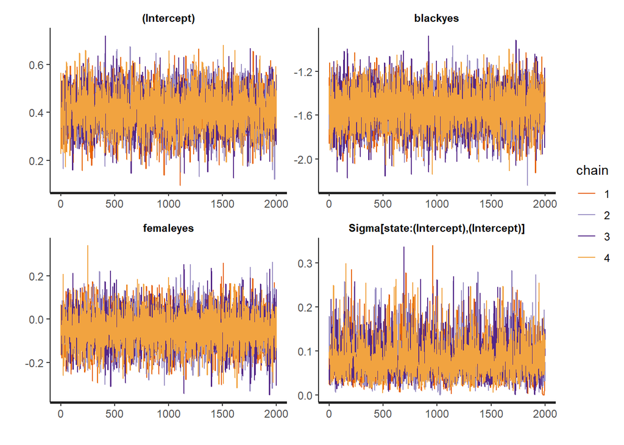

```r
stan_trace(mod_bin_ri,pars=c("(Intercept)","blackyes","femaleyes","Sigma[state:(Intercept),(Intercept)]"))
```

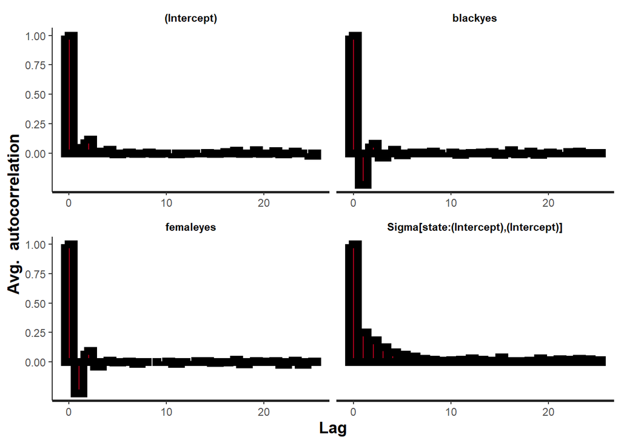

```r
stan_ac(mod_bin_ri,pars=c("(Intercept)","blackyes","femaleyes","Sigma[state:(Intercept),(Intercept)]"))
```

Sigma[state:(Intercept),(Intercept)] might be problematic interms of autocorrelation

```r
waic(mod_bin)
```

```
##
## Computed from 8000 by 2591 log-likelihood matrix.
##
##           Estimate   SE
## elpd_waic  -1732.0 11.4
## p_waic         3.0  0.1
## waic        3463.9 22.7
```

```r
waic(mod_bin_ri)
```

```
##
## Computed from 8000 by 2591 log-likelihood matrix.
##
##           Estimate   SE
## elpd_waic  -1722.7 12.1
## p_waic        22.5  0.3
## waic        3445.4 24.2
```

It is better to use model with random intercept.

## Extra Models:

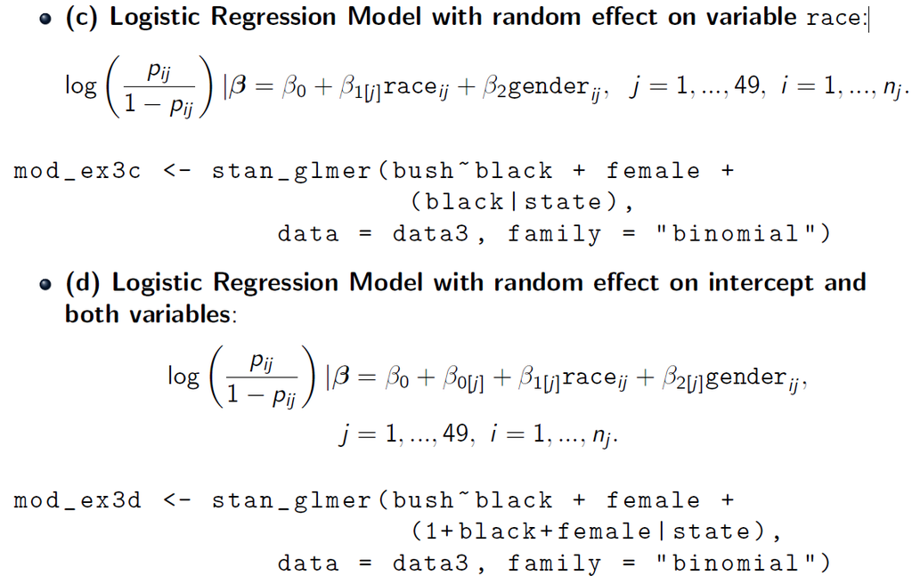

Additional Models:

## Poisson Regression Model:

The Poisson model with random effects is usually assumed in order to take into account the eventual presence of overdispersion or underdispersion. The Poisson distribution has only one parameter (E[Y] = V[Y] = lambda), and in fact the variance increases with the mean.

Simple Poisson Model:

$$y_i|\mu_i \sim Poisson(\mu_i)$$
$$log(\mu_i)|\beta =
\beta_0+\beta_1log(x_i+10)+\beta_2x_2$$
$$=\beta_0+\beta_1log(quoline_i+10)+\beta_2quoline_i$$
$$=\beta_0+\beta_1logquoline+\beta_2quoline$$

$$\beta_k \sim N(0,C)$$

```r
df4=read.csv("Data_Ex_4.csv",header=T)
head(df4)
```

```
##   colonies quinoline log_quinoline plate
## 1       15         0      2.302585     A
## 2       16        10      2.995732     A
## 3       16        33      3.761200     A
## 4       27       100      4.700480     A
## 5       33       333      5.837730     A
## 6       20      1000      6.917706     A
```

```r
pois=stan_glm(colonies~quinoline+log_quinoline,data=df4,family="poisson",prior=normal(0,10,autoscale=T)
              ,prior_intercept=normal(0,10,autoscale = T))
prior_summary(pois)
```

```
## Priors for model 'pois'
## ------
## Intercept (after predictors centered)
##  ~ normal(location = 0, scale = 10)
##
## Coefficients
##   Specified prior:
##     ~ normal(location = [0,0], scale = [10,10])
##   Adjusted prior:
##     ~ normal(location = [0,0], scale = [0.027,6.091])
## ------
## See help('prior_summary.stanreg') for more details
```

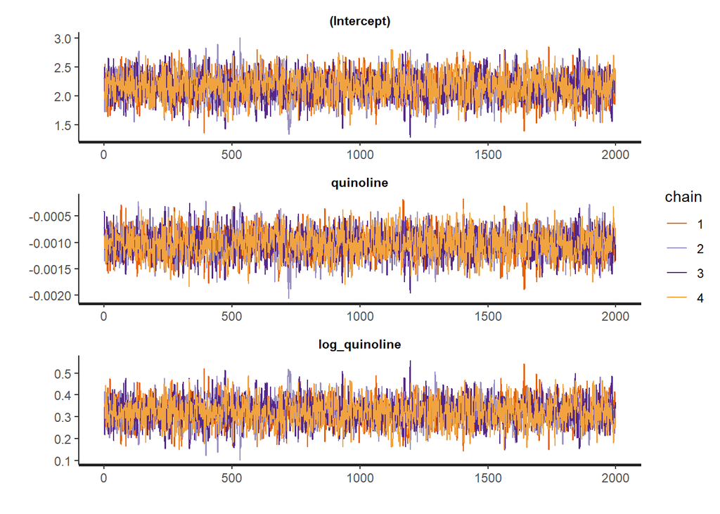

```r
pois_new=update(pois,iter=4000)
stan_trace(pois_new,nrow=3,ncol=1)
```

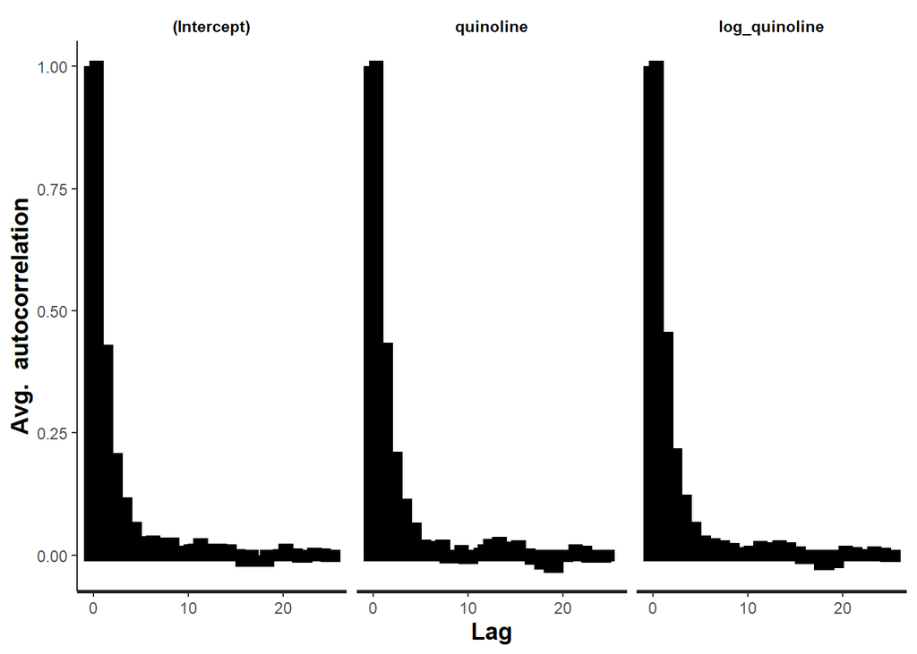

```r
stan_ac(pois_new)
```

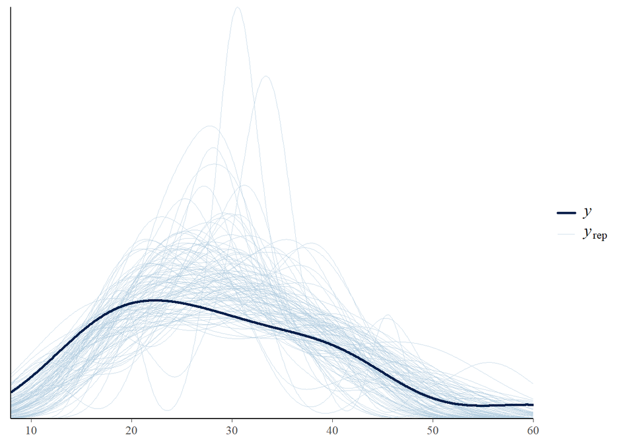

```r
y_tilde4a <- posterior_predict(pois_new)
ppc_dens_overlay (y=df4$colonies ,yrep=y_tilde4a[1100:1200,])
```

## Poisson Regression Model with random effects:

To take into account the eventual presence of overdispersion, the term lambdaj , that is plate-speciffic is included in the linear predictor

```r
mod_ex4b <- stan_glmer (formula =
colonies ~ quinoline +log_quinoline+(1|plate),
data = df4 ,
family ="poisson",
prior = normal (0 ,10 , autoscale =T),
prior_intercept = normal (0 ,10 , autoscale =T))
mod_ex4b <- update(mod_ex4b , iter =8000)
summary (mod_ex4b)
```

```
##
## Model Info:
##  function:     stan_glmer
##  family:       poisson [log]
##  formula:      colonies ~ quinoline + log_quinoline + (1 | plate)
##  algorithm:    sampling
##  sample:       16000 (posterior sample size)
##  priors:       see help('prior_summary')
##  observations: 18
##  groups:       plate (3)
##
## Estimates:
##                                        mean   sd   10%   50%   90%
## (Intercept)                           2.1    0.4  1.7   2.1   2.6
## quinoline                             0.0    0.0  0.0   0.0   0.0
## log_quinoline                         0.3    0.1  0.2   0.3   0.4
## b[(Intercept) plate:A]               -0.3    0.3 -0.6  -0.3   0.1
## b[(Intercept) plate:B]                0.0    0.3 -0.4   0.0   0.4
## b[(Intercept) plate:C]                0.3    0.3 -0.1   0.3   0.6
## Sigma[plate:(Intercept),(Intercept)]  0.4    0.8  0.0   0.2   0.9
##
## Fit Diagnostics:
##            mean   sd   10%   50%   90%
## mean_PPD 29.1    1.8 26.8  29.1  31.5
##
## The mean_ppd is the sample average posterior predictive distribution of the outcome variable (for details see help('summary.stanreg')).
##
## MCMC diagnostics
##                                      mcse Rhat n_eff
## (Intercept)                          0.0  1.0   4706
## quinoline                            0.0  1.0   7694
## log_quinoline                        0.0  1.0   7619
## b[(Intercept) plate:A]               0.0  1.0   3952
## b[(Intercept) plate:B]               0.0  1.0   3927
## b[(Intercept) plate:C]               0.0  1.0   3921
## Sigma[plate:(Intercept),(Intercept)] 0.0  1.0   3035
## mean_PPD                             0.0  1.0  15329
## log-posterior                        0.0  1.0   4437
##
## For each parameter, mcse is Monte Carlo standard error, n_eff is a crude measure of effective sample size, and Rhat is the potential scale reduction factor on split chains (at convergence Rhat=1).
```

Likelihood:

$$y_{ij}|\mu_{ij} \sim
Poi(\mu_{ij})$$
$$log(\mu_{ij})|\beta,\lambda_j=\beta_0+\beta_1log(x_{ij}+10)+\beta_2x_{ij}+\lambda_j$$

Priors:

$$\lambda_j|\sigma^2_\lambda \sim
N(0,\sigma^2_{\lambda})$$
$$\beta_k
\sim N(0,c)$$
Hyperprior:

$$\sigma_\lambda \sim
\pi(\sigma_\lambda)$$

```r
prior_summary(mod_ex4b)
```

```
## Priors for model 'mod_ex4b'
## ------
## Intercept (after predictors centered)
##  ~ normal(location = 0, scale = 10)
##
## Coefficients
##   Specified prior:
##     ~ normal(location = [0,0], scale = [10,10])
##   Adjusted prior:
##     ~ normal(location = [0,0], scale = [0.027,6.091])
##
## Covariance
##  ~ decov(reg. = 1, conc. = 1, shape = 1, scale = 1)
## ------
## See help('prior_summary.stanreg') for more details
```

```r
summary(mod_ex4b)
```

```
##
## Model Info:
##  function:     stan_glmer
##  family:       poisson [log]
##  formula:      colonies ~ quinoline + log_quinoline + (1 | plate)
##  algorithm:    sampling
##  sample:       16000 (posterior sample size)
##  priors:       see help('prior_summary')
##  observations: 18
##  groups:       plate (3)
##
## Estimates:
##                                        mean   sd   10%   50%   90%
## (Intercept)                           2.1    0.4  1.7   2.1   2.6
## quinoline                             0.0    0.0  0.0   0.0   0.0
## log_quinoline                         0.3    0.1  0.2   0.3   0.4
## b[(Intercept) plate:A]               -0.3    0.3 -0.6  -0.3   0.1
## b[(Intercept) plate:B]                0.0    0.3 -0.4   0.0   0.4
## b[(Intercept) plate:C]                0.3    0.3 -0.1   0.3   0.6
## Sigma[plate:(Intercept),(Intercept)]  0.4    0.8  0.0   0.2   0.9
##
## Fit Diagnostics:
##            mean   sd   10%   50%   90%
## mean_PPD 29.1    1.8 26.8  29.1  31.5
##
## The mean_ppd is the sample average posterior predictive distribution of the outcome variable (for details see help('summary.stanreg')).
##
## MCMC diagnostics
##                                      mcse Rhat n_eff
## (Intercept)                          0.0  1.0   4706
## quinoline                            0.0  1.0   7694
## log_quinoline                        0.0  1.0   7619
## b[(Intercept) plate:A]               0.0  1.0   3952
## b[(Intercept) plate:B]               0.0  1.0   3927
## b[(Intercept) plate:C]               0.0  1.0   3921
## Sigma[plate:(Intercept),(Intercept)] 0.0  1.0   3035
## mean_PPD                             0.0  1.0  15329
## log-posterior                        0.0  1.0   4437
##
## For each parameter, mcse is Monte Carlo standard error, n_eff is a crude measure of effective sample size, and Rhat is the potential scale reduction factor on split chains (at convergence Rhat=1).
```

model <- update (model , adapt _ delta =.99)

adapt delta is the target average proposal acceptance probability In general you should not need to change adapt delta unless you see a warning message about divergent transitions, in which case you can increase adapt delta from the default to a value closer to 1 (e.g. from 0.95 to 0.99, or from 0.99 to 0.999, etc). The step size used by the numerical integrator is a function of adapt delta in that increasing adapt delta will result in a smaller step size and fewer divergences. Increasing adapt delta will typically result in a slower sampler, but it will always lead to a more robust sampler.

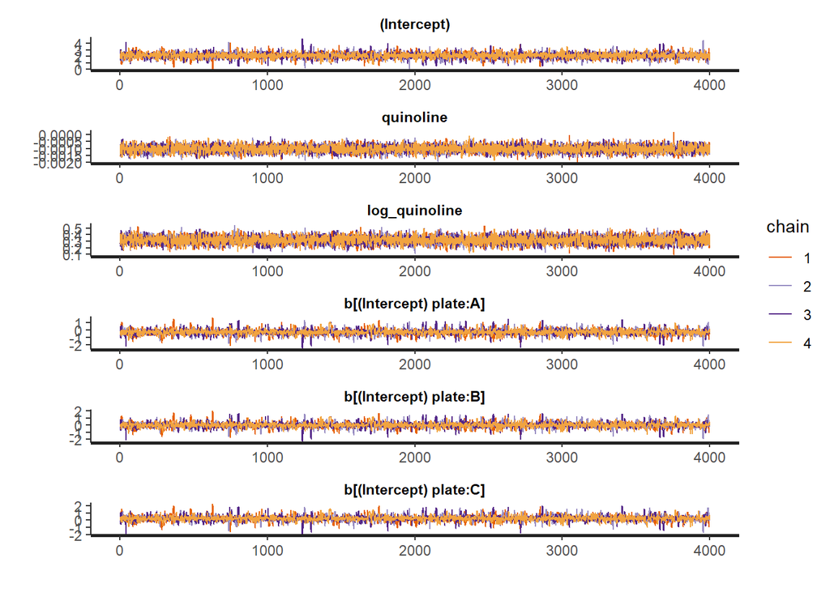

```r
stan_trace(mod_ex4b,nrow=6,ncol=1)
```

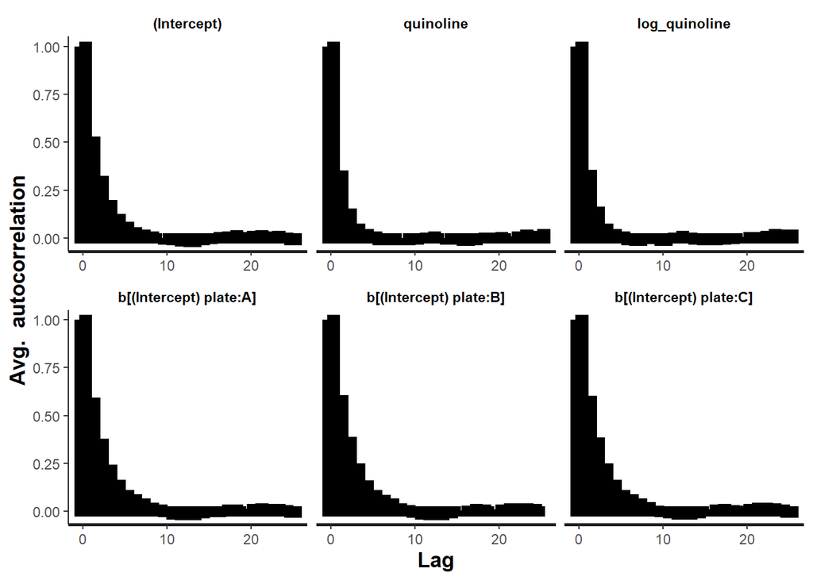

```r
stan_ac(mod_ex4b)
```

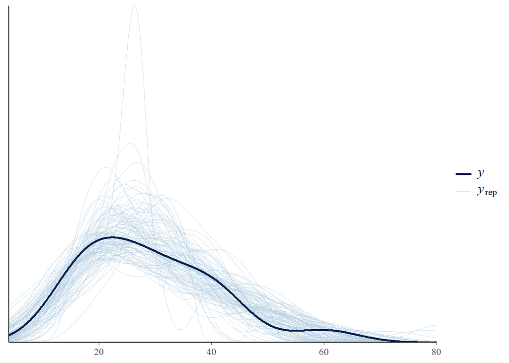

```r
y_tilde4b=posterior_predict(mod_ex4b)
ppc_dens_overlay(y=df4$colonies,yrep=y_tilde4b[1100:1200,])
```

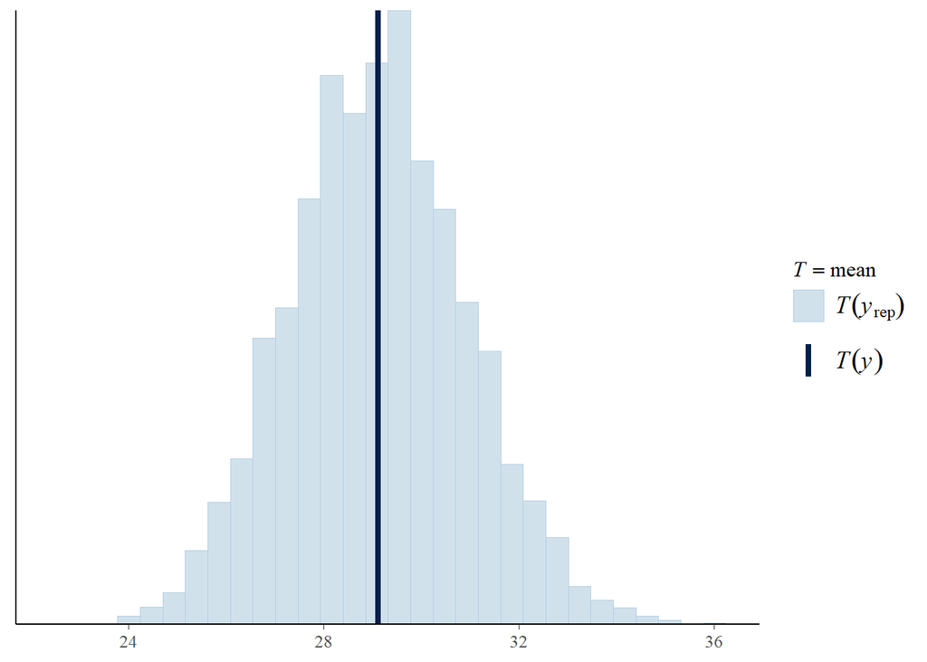

```r
ppc_stat(y=df4$colonies,yrep=y_tilde4b,stat="mean")
```

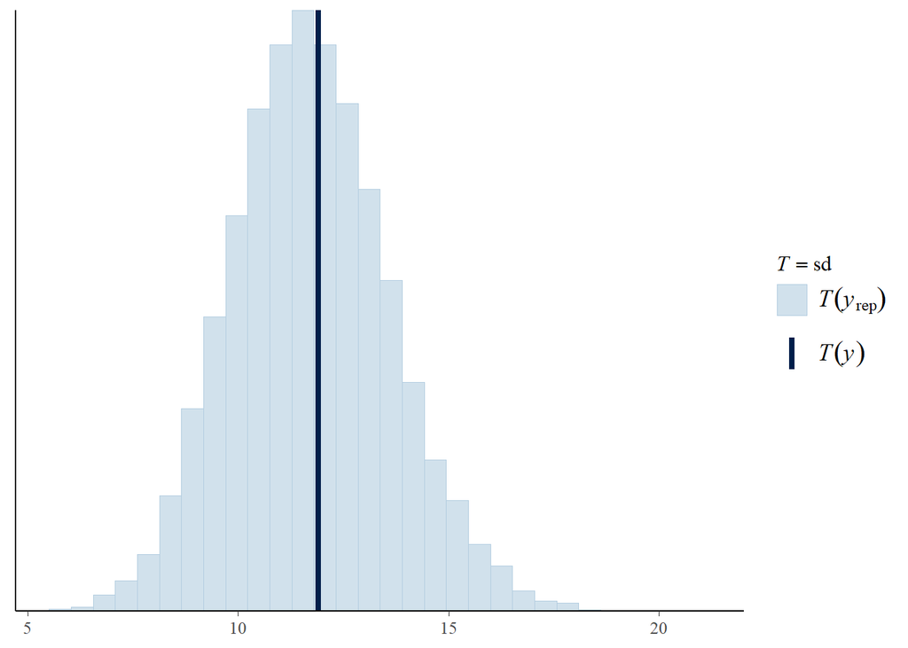

```r
ppc_stat(y=df4$colonies,yrep=y_tilde4b,stat="sd")
```

## Suppose now that we want to use our model to perform inference on a new covariate pattern quinoline = 500 and plate = “A”

Generating new dataset:

```r
df4_new=data.frame(quinoline =500 ,
log_quinoline=log(500+10),plate ="A")
df4_new
```

```
##   quinoline log_quinoline plate
## 1       500      6.234411     A
```

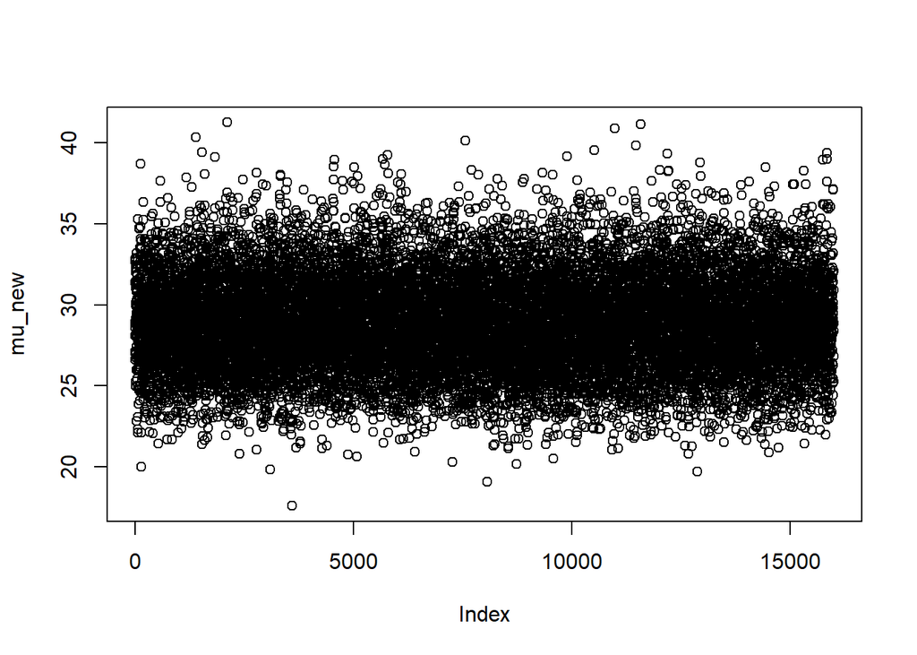

```r
mu_new=posterior_epred(mod_ex4b,newdata=df4_new)
plot(mu_new)
```

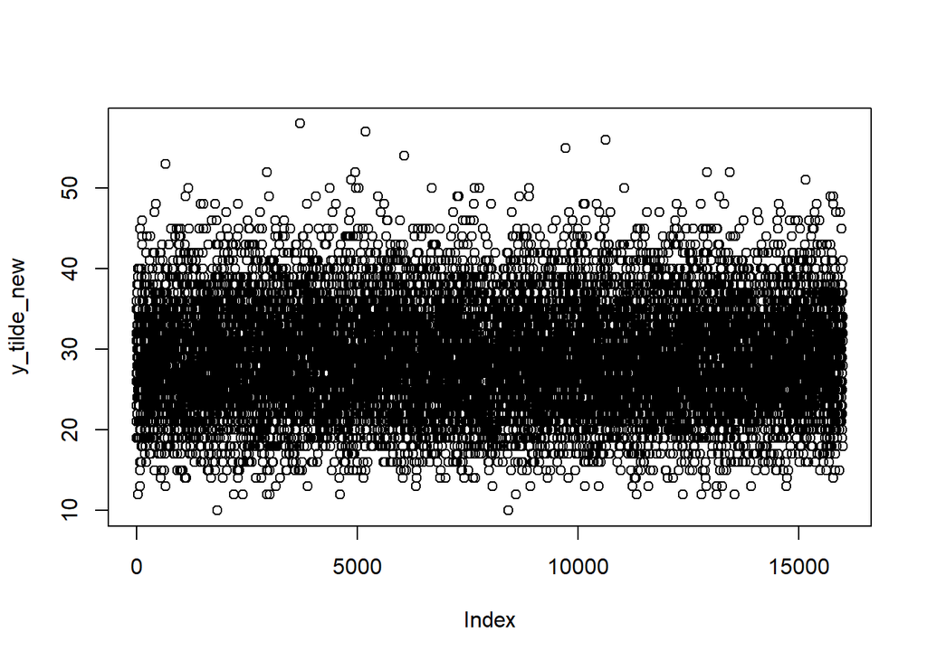

```r
y_tilde_new=posterior_predict(mod_ex4b,newdata = df4_new)
plot(y_tilde_new)
```

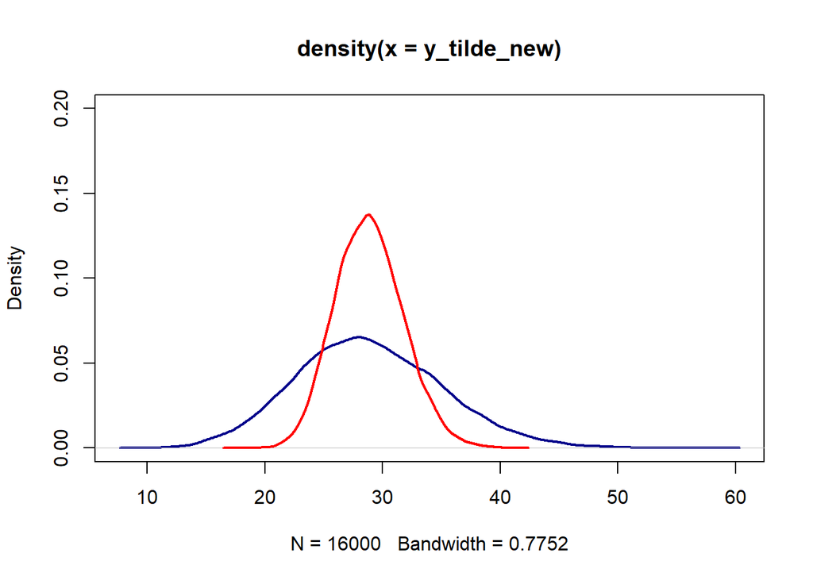

```r
plot(density(y_tilde_new),ylim=c(0,0.2),lwd=2,col="darkblue")
lines(density(mu_new),col="red",lwd=2)
```

```r
mean(mu_new)
```

```
## [1] 28.87816
```

```r
sd(mu_new)
```

```
## [1] 2.90107
```

```r
mean(y_tilde_new)
```

```
## [1] 28.87125
```

```r
sd(y_tilde_new)
```

```
## [1] 6.185816
```